# Workshop Intro Draft

Eric Reed

6/13/2019

# Working with `data.frame` objects

Looking at `scaledcounts` we can see that the first column, “ensgene”, gives the gene identifier for each gene, while each successive column gives the expression values for this gene.

```r
# Use the `ensgene` column to extract the gene expression values for "ENSG00000002549".
```

```r
row2extract <- scaledcounts$ensgene == "ENSG00000002549"
scaledcounts[row2extract,]
```

```
##            ensgene SRR1039508 SRR1039509 SRR1039512 SRR1039513 SRR1039516
## 23 ENSG00000002549       1460       1274       1280        980       1428
##    SRR1039517 SRR1039520 SRR1039521
## 23       1770        829       1003
```

This is okay, but a little clunky. Alternatively we can set the gene identifiers as row names to index rows directly.

```r
# 1  Set the gene identifiers to row names in `scaledcounts`.
# 2  Remove the `ensgene` column.
# 3  Extract the gene expression values using the string "ENSG00000002549" directly.
```

```r
rownames(scaledcounts) <- scaledcounts$ensgene
scaledcounts <- scaledcounts[,-1]
scaledcounts <- scaledcounts["ENSG00000002549",]
```

### Asking R for help

Alternative to steps 1 + 2 above, we could have set gene identifiers to row names when we read in the file.

```r
# 1 Look up the help page for `read.csv()` using `?read.csv`, scroll down to the `row.names` in the "Arguments" section.
# 2 Use these instructions to reread in `scaledcounts` and set the gene identifiers to row names automatically.
```

```r
scaledcounts <- read.csv("airway_scaledcounts.csv", row.names = 1)
```

# Working with `matrix` objects

The main difference between a `data.frame` object and a `matrix` object is that each column of a `data.frame` is free to have it’s own format, whereas all values within an entire `matrix` must have the same format. One nice thing about `matrix` objects is that functions in R can be applied to all values at once. Note, that after setting the gene identifiers to row names, all values in `scaledcounts` is now a number.

For gene expression it is common to work with log-scaled count data because these tend to adhere more closely to normal distributions than count data. The one caveat to this that log(0) = -Inf. To overcome this, it is common practice to add a small value prior to performing log-transformations, most commonly by adding one to every value, log(1) = 0.

```r
# 1 Use the `as.matrix()` function to convert `scaledcounts` to a matrix.
# 2 Add a pseudocount to every value.
# 3 Use the `log2()` function to log-scale the matrix.
```

```r
scaledcounts <- as.matrix(scaledcounts)
scaledcounts <- scaledcounts + 1
scaledcounts <- log2(scaledcounts)
```

# Running simple comparative statistical analyses

Later in this workshop, we will use a fancy Bioconductor package to run differential gene expression analysis. The basis for this type of analysis is common when analyzing high-throughput data. It has the following steps

1. Extract the expression values for a single gene.
2. Run compare the mean expression between two groups using a statistical test.
3. Repeat steps 1 + 2 for every gene.

### Running one test

The t-test is a common choice for performing a differential analysis. The “dex” column in `metadata` gives group values for treated and control samples.

```r
# 1 Create a new data.frame called `genedata` with two columns: 1) log-transformed expression values of "ENSG00000002549" and 2) group values from the "dex" variable. Call the columns "ex" and "group", respectively.
# 2 Run the following to use the `t.test()` function to compare the log transformed expression values between treated and control samples with pooled variance (var.equal = TRUE).
ttestRes <- t.test(ex ~ group, data = genedata, var.equal = TRUE)
```

```r
genedata <- data.frame(ex = scaledcounts["ENSG00000002549",], group = metadata$dex)
ttestRes <- t.test(ex ~ group, data = genedata, var.equal = TRUE)
print(ttestRes)
```

```
##
##  Two Sample t-test
##
## data:  ex by group
## t = -0.0024858, df = 6, p-value = 0.9981
## alternative hypothesis: true difference in means is not equal to 0
## 95 percent confidence interval:
##  -0.6724886  0.6711236
## sample estimates:
## mean in group control mean in group treated
##              10.25339              10.25407
```

Note that the syntax at the begining of this function, you will see it a lot. Look up ?formula for more information. This is common in functions for statistical modelling, as well as base R plotting functions. For example, instead of running a t-test we could run a linear model.

```r
lmRes <- lm(ex ~ group, data = genedata)
print(summary(lmRes))
```

```
##
## Call:
## lm(formula = ex ~ group, data = genedata)
##
## Residuals:
##      Min       1Q   Median       3Q      Max
## -0.55642 -0.29089  0.06594  0.23539  0.53628
##
## Coefficients:
##               Estimate Std. Error t value Pr(>|t|)
## (Intercept)  1.025e+01  1.941e-01  52.815 3.09e-09 ***
## grouptreated 6.825e-04  2.746e-01   0.002    0.998
## ---
## Signif. codes:  0 '***' 0.001 '**' 0.01 '*' 0.05 '.' 0.1 ' ' 1
##
## Residual standard error: 0.3883 on 6 degrees of freedom
## Multiple R-squared:  1.03e-06,   Adjusted R-squared:  -0.1667
## F-statistic: 6.179e-06 on 1 and 6 DF,  p-value: 0.9981
```

Note, that the p-value for the linear model is equal to the p-value for the t-test. This is because simple linear regression models are equivalent to a pooled variance t-test.

Next, we can use a similar syntax to create boxplots of the expression values for either group.

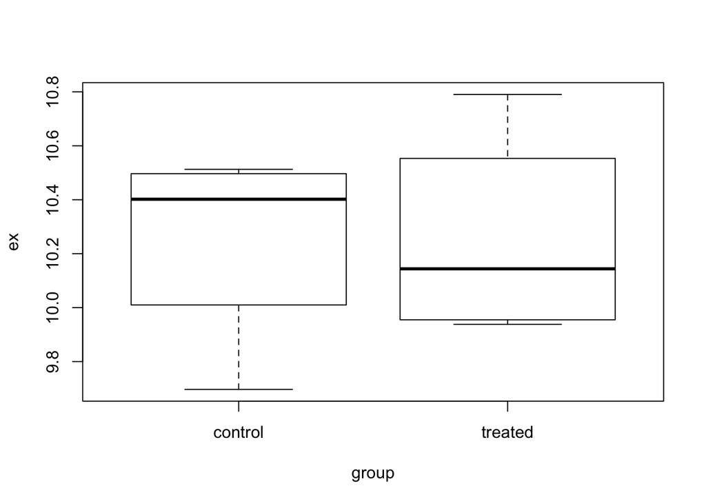

```r
boxplot(ex ~ group, data = genedata)
```

As we can see, the difference in mean is very small relative to the variance, hence the large p-value.

### Wrapper functions

If we want to run a test one any gene we can greatly reduce the amount of code we need to write by writing a function that takes a gene identifier as an argument, runs the t-test, and returns information we are interested in. For example, below is a function that takes the arguments, `geneid` and returns a vector with two values: the difference in mean and p-value.

```r
# Function to run ttest for a given gene ID
ttestGene <- function(geneid) {

    # Create data matrix
    genedata <- data.frame(ex = scaledcounts[geneid,], group = metadata$dex)

    # Run t-test
    ttestRes <- t.test(ex ~ group, data = genedata)

    # Get difference in mean
    diffMean <- ttestRes$estimate[2] - ttestRes$estimate[1]

    # Get difference and p-value
    results <- c(diffMean, pvalue = ttestRes$p.value)

    # Given these values a name
    names(results) <- c("diff", "pvalue")

    return(results)
}

# Run it on "ENSG00000002549"
ttestGene("ENSG00000002549")
```

```
##         diff       pvalue
## 0.0006824895 0.9980973255
```

### Apply loops

We can run this analysis using an apply loop. In are there are several choices of apply loops, for this case we will use the `sapply()` function. `sapply()` takes two arguments: a vector and a function. You may want to check the help page, `?apply`, for other options.

```r
# 1 Run sapply for the first 1000 genes in `scaledcounts` using their names and the `ttestGene()` function.  Write the ouput to an object called `res`.
# 2 Transpose the output with t().
```

```r
res <- sapply(rownames(scaledcounts)[1:1000], ttestGene)
res <- t(res)
print(head(res))
```

```
##                        diff    pvalue
## ENSG00000000003 -0.52535964 0.1775871
## ENSG00000000005  0.00000000       NaN
## ENSG00000000419  0.03593936 0.8940656
## ENSG00000000457 -0.14487982 0.5330695
## ENSG00000000460 -0.29209225 0.1571889
## ENSG00000000938 -0.64624063 0.1975805
```

### Matrix operations

Loops are great and often necessary, but whenever possible utilizing matrix operations is a great way to speed up runtime. For example, the maximum likelihood estimates for a linear regression model can be estimated using the following formula,
$$\hat{\beta} = (X^TX)^{-1}X^Ty.$$
Here, X is and $N\times P$ matrix of variables, and $y$ can be a vector of outcome variables, in this case gene expression values for specific gene. $X^T$ denotes that a given matrix is transposed and $()^{-1} denotes taking the inverse of the items in the parathesis.

```r
X <- model.matrix(~ group, data = genedata)
print(X)
```

```
##            (Intercept) grouptreated
## SRR1039508           1            0
## SRR1039509           1            1
## SRR1039512           1            0
## SRR1039513           1            1
## SRR1039516           1            0
## SRR1039517           1            1
## SRR1039520           1            0
## SRR1039521           1            1
## attr(,"assign")
## [1] 0 1
## attr(,"contrasts")
## attr(,"contrasts")$group
## [1] "contr.treatment"
```

The three basic matrix operations functions in R are: 1. `t()`: Transpose matrix input. 2. `solve()`: Take the inverse of matrix input. 3. `%*%`: Multiply matrices on the left and right.

```r
# 1 Use the formula for the maximum likelihood estimates for a linear regression model above to generate the difference in mean of log transformed expression values between treated and control samples for "ENSG00000002549".
```

```r
y <- scaledcounts["ENSG00000002549",]
beta <- solve(t(X) %*% X) %*% t(X) %*% y
print(beta)
```

```
##                      [,1]
## (Intercept)  1.025339e+01
## grouptreated 6.824895e-04
```

In actuality, $y$ need not be a vector, but instead a $N \times Q$ matrix, where $Q$ is a set of variables for which you’d like to indepedently test the relationships to $X$.

```r
# 1 Use the formula for the maximum likelihood estimates for a linear regression model above to estimate the difference in log transformed expression values between treated and control samples for the first 1000 genes in `scaledcounts`.
```

```r
y <- t(scaledcounts[1:1000,])
beta <- solve(t(X) %*% X) %*% t(X) %*% y
print(head(t(beta)))
```

```
##                 (Intercept) grouptreated
## ENSG00000000003   9.7928925  -0.52535964
## ENSG00000000005   0.0000000   0.00000000
## ENSG00000000419   9.0085507   0.03593936
## ENSG00000000457   8.4106990  -0.14487982
## ENSG00000000460   6.5976711  -0.29209225
## ENSG00000000938   0.6462406  -0.64624063
```